# Econ 10R Week 4 Tuesday - Midterm Solutions

Luke Zhang

# 1 Question 1 (3pts)

1. Load and store the `college.csv` dataset in R. (1pt)

```r
college <- read.csv("college.csv")
```

2. Rename the first column `X` to `College`. (1pt)

```r
colnames(college)[1] <- "College"
head(college)
```

```
##                        College Private Apps Accept Enroll Top10perc Top25perc
## 1 Abilene Christian University     Yes 1660   1232    721        23        52
## 2           Adelphi University     Yes 2186   1924    512        16        29
## 3               Adrian College     Yes 1428   1097    336        22        50
## 4          Agnes Scott College     Yes  417    349    137        60        89
## 5    Alaska Pacific University     Yes  193    146     55        16        44
## 6            Albertson College     Yes  587    479    158        38        62
##   F.Undergrad P.Undergrad Outstate Room.Board Books Personal PhD Terminal
## 1        2885         537     7440       3300   450     2200  70       78
## 2        2683        1227    12280       6450   750     1500  29       30
## 3        1036          99    11250       3750   400     1165  53       66
## 4         510          63    12960       5450   450      875  92       97
## 5         249         869     7560       4120   800     1500  76       72
## 6         678          41    13500       3335   500      675  67       73
##   S.F.Ratio perc.alumni Expend Grad.Rate
## 1      18.1          12   7041        60
## 2      12.2          16  10527        56
## 3      12.9          30   8735        54
## 4       7.7          37  19016        59
## 5      11.9           2  10922        15
## 6       9.4          11   9727        55
```

3. Separate the colleges into private and non-private, each with its own data frame. (1pt)

```r
unique(college$Private)
```

```
## [1] "Yes" "No"
```

```r
college_private <- filter(college, Private == "Yes")
college_nonprivate <- filter(college, Private == "No")
```

# 2 Question 2 (7pts)

1. Find the college with the highest estimated book cost. (1pt)

```r
head(arrange(college, desc(Books))[, c("College", "Books")])
```

```
##                            College Books
## 1      Center for Creative Studies  2340
## 2               Bradley University  2000
## 3                  Bowdoin College  1495
## 4              Wesleyan University  1400
## 5           University of the Arts  1300
## 6 Rensselaer Polytechnic Institute  1230
```

It is the Center for Creative Studies with 2340 dollars.

2. For both private and non-private colleges, find the one that has the highest percentage of faculty with Ph.D.’s. What is weird about the result? (2pts)

```r
head(arrange(college_private, desc(PhD))[, c("College", "PhD")])
```

```
##                             College PhD
## 1                 Bryn Mawr College 100
## 2               Harvey Mudd College 100
## 3                    Pitzer College 100
## 4                  Brown University  99
## 5         Claremont McKenna College  99
## 6 Hobart and William Smith Colleges  99
```

```r
head(arrange(college_nonprivate, desc(PhD))[, c("College", "PhD")])
```

```
##                                    College PhD
## 1        Texas A&M University at Galveston 103
## 2 New Mexico Institute of Mining and Tech.  99
## 3               University of North Dakota  97
## 4      University of Alabama at Birmingham  96
## 5       University of California at Irvine  96
## 6                 University of Washington  96
```

```r
head(arrange(college, desc(PhD))[, c("College", "PhD", "Private")], 10)
```

```
##                                     College PhD Private
## 1         Texas A&M University at Galveston 103      No
## 2                         Bryn Mawr College 100     Yes
## 3                       Harvey Mudd College 100     Yes
## 4                            Pitzer College 100     Yes
## 5                          Brown University  99     Yes
## 6                 Claremont McKenna College  99     Yes
## 7         Hobart and William Smith Colleges  99     Yes
## 8     Massachusetts Institute of Technology  99     Yes
## 9  New Mexico Institute of Mining and Tech.  99      No
## 10                    University of Chicago  99     Yes
```

Several colleges tie for private colleges, and Texas A&M University at Galveston is the highest for non-private. The latter has a percentage that is higher than 100, which is strange.

3. Find the college with the highest and the lowest acceptance rate. (2pts)

```r
college_accept <- mutate(college, AcceptRate = Accept / Apps)
head(arrange(college_accept, desc(AcceptRate))[, c("College", "Apps", "Accept", "AcceptRate")], 10)
```

```
##                             College Apps Accept AcceptRate
## 1          Emporia State University 1256   1256  1.0000000
## 2         Mayville State University  233    233  1.0000000
## 3       MidAmerica Nazarene College  331    331  1.0000000
## 4      Southwest Baptist University 1093   1093  1.0000000
## 5  University of Wisconsin-Superior  910    910  1.0000000
## 6               Wayne State College 1373   1373  1.0000000
## 7          Arkansas Tech University 1734   1729  0.9971165
## 8    Southwestern Adventist College  321    318  0.9906542
## 9                 Pikeville College  404    400  0.9900990
## 10              Mount Marty College  279    276  0.9892473
```

```r
head(arrange(college_accept, AcceptRate)[, c("College", "Apps", "Accept", "AcceptRate")], 10)
```

```
##                  College  Apps Accept AcceptRate
## 1   Princeton University 13218   2042  0.1544863
## 2     Harvard University 13865   2165  0.1561486
## 3        Yale University 10705   2453  0.2291453
## 4        Amherst College  4302    992  0.2305904
## 5       Brown University 12586   3239  0.2573494
## 6  Georgetown University 11115   2881  0.2591993
## 7      Dartmouth College  8587   2273  0.2647025
## 8        Duke University 13789   3893  0.2823265
## 9    Columbia University  6756   1930  0.2856720
## 10      Williams College  4186   1245  0.2974200
```

Several colleges tie for the highest acceptance rate. Princeton has the lowest rate.

4. Find the college that has the lowest graduation rate among all colleges with the full word “California” in their names. (2pts)

```r
college_cal <- filter(college, str_detect(College, "California"))
arrange(college_cal, Grad.Rate)[, c("College", "Grad.Rate")]
```

```
##                                 College Grad.Rate
## 1           Southern California College        43
## 2       California Polytechnic-San Luis        59
## 3        California Lutheran University        60
## 4 California State University at Fresno        61
## 5    University of California at Irvine        66
## 6     University of Southern California        68
## 7      St. Mary's College of California        78
## 8  University of California at Berkeley        78
```

We can use the `str_detect` function of R. It looks like Southern California College has the lowest graduation rate.

# 3 Question 3 (10pts)

1. Load and store the `air.csv` dataset in R. (1pt)

```r
air <- read.csv("air.csv")
head(air)
```

```
##   station     date longitude latitude AQI CO_24h NO2_24h O3_24h PM10_24h
## 1   1001A 20150102   116.366  39.8673 117  1.424      72     65       91
## 2   1001A 20150103   116.366  39.8673 169  1.588      79     50      101
## 3   1001A 20150104   116.366  39.8673 257  3.892     128     32      250
## 4   1001A 20150105   116.366  39.8673 206  3.669     137     31      242
## 5   1001A 20150106   116.366  39.8673  18  2.279      64     66      144
## 6   1001A 20150107   116.366  39.8673 170  0.912      50     62       72
##   PM2.5_24h SO2_24h
## 1        48      31
## 2        54      38
## 3       157      89
## 4       148      73
## 5        68      52
## 6        43      28
```

2. Using information in `date`, generate three variables for each observation: `year`, `month`, `day`. (2pts)

```r
air <- separate(air, date, into = c("year", "month", "day"), sep = c(4, 6), remove = FALSE)
head(select(air, date, year, month, day))
```

```
##       date year month day
## 1 20150102 2015    01  02
## 2 20150103 2015    01  03
## 3 20150104 2015    01  04
## 4 20150105 2015    01  05
## 5 20150106 2015    01  06
## 6 20150107 2015    01  07
```

Alternatively, using functions from the `lubridate` package:

```r
air <- read.csv("air.csv")
air$date_format <- as.Date(as.character(air$date), format = "%Y%m%d")
air <- mutate(air,
              year = year(date_format),
              month = month(date_format),
              day = day(date_format))
head(select(air, date, year, month, day))
```

```
##       date year month day
## 1 20150102 2015     1   2
## 2 20150103 2015     1   3
## 3 20150104 2015     1   4
## 4 20150105 2015     1   5
## 5 20150106 2015     1   6
## 6 20150107 2015     1   7
```

3. Which station has the highest average AQI (worst air quality) across all dates? (1pt)

```r
head(arrange(summarise(group_by(air, station), count = n(), average_AQI = mean(AQI, na.rm = TRUE)), desc(average_AQI)))
```

```
## # A tibble: 6 × 3
##   station count average_AQI
##   <chr>   <int>       <dbl>
## 1 2700A     730        260.
## 2 2699A     730        247.
## 3 2702A     730        226.
## 4 2698A     730        224.
## 5 2701A     730        217.
## 6 2695A     730        191.
```

Clearly station 2700A has the worst average AQI.

4. For each station, find the dates with the best and worst air qualities (indicated by the AQI). Store these observations in a single, new data frame. (2pts)

```r
air_extrema <- filter(group_by(air, station),
                      AQI == min(AQI, na.rm = TRUE) | AQI == max(AQI, na.rm = TRUE))[, c("station", "year", "month", "day", "AQI")]
head(arrange(air_extrema, station, AQI), 10)
```

```
## # A tibble: 10 × 5
## # Groups:   station [2]
##    station  year month   day   AQI
##    <chr>   <dbl> <dbl> <int> <int>
##  1 1001A    2016    10     8    12
##  2 1001A    2015     2    22   500
##  3 1001A    2015    12    25   500
##  4 1001A    2015    12    30   500
##  5 1001A    2016     1     3   500
##  6 1001A    2016     3     5   500
##  7 1001A    2016     5     6   500
##  8 1001A    2016    12     4   500
##  9 1001A    2016    12    20   500
## 10 1002A    2015     9    11     8
```

Alternatively, we can use the `rbind` function to do things separately:

```r
air_max <- filter(group_by(air, station), AQI == max(AQI, na.rm = TRUE))
air_min <- filter(group_by(air, station), AQI == min(AQI, na.rm = TRUE))
air_extrema <- arrange(rbind(air_max, air_min), station, AQI, year, month, day)[, c("station", "year", "month", "day", "AQI")]
head(air_extrema, 10)
```

```
## # A tibble: 10 × 5
## # Groups:   station [2]
##    station  year month   day   AQI
##    <chr>   <dbl> <dbl> <int> <int>
##  1 1001A    2016    10     8    12
##  2 1001A    2015     2    22   500
##  3 1001A    2015    12    25   500
##  4 1001A    2015    12    30   500
##  5 1001A    2016     1     3   500
##  6 1001A    2016     3     5   500
##  7 1001A    2016     5     6   500
##  8 1001A    2016    12     4   500
##  9 1001A    2016    12    20   500
## 10 1002A    2015     9    11     8
```

5. What is the relationship between air qualities across two consecutive days? Find the correlation coefficient, and plot the relationship. Bonus point if the graph looks great. (2pts)

```r
air_lag <- mutate(group_by(air, station), AQI_lag = lag(AQI))
air_lag <- filter(air_lag, AQI != "NA" & AQI_lag != "NA")
cor(air_lag$AQI, air_lag$AQI_lag)
```

```
## [1] 0.5770228
```

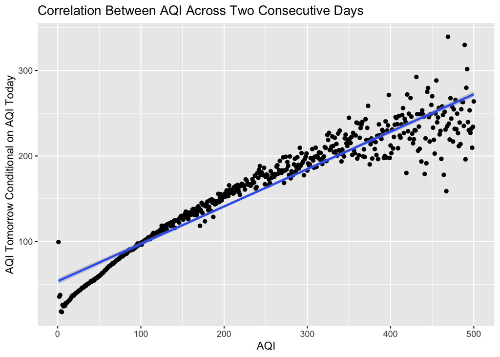

```r
air_lag <- summarise(group_by(air_lag, AQI_lag),
                     AQI_mean = mean(AQI))
ggplot(data = air_lag, aes(x = AQI_lag, y = AQI_mean)) +
  geom_point() +
  geom_smooth(method = lm) +
  labs(title = "Correlation Between AQI Across Two Consecutive Days",
       x = "AQI", y = "AQI Tomorrow Conditional on AQI Today")
```

6. For each unique date, find the station with the highest index of each of the six pollutants (note that this does not include `AQI`). Store the data in a data frame with the format where each date is an observation, each pollutant a variable, and the values of the variables are the station number. If there are multiple stations with the same index for the same pollutant on the same day, just pick whichever one you want as the value for that variable. (2pts)

```r
CO <- arrange(filter(group_by(air, date), CO_24h == max(CO_24h, na.rm = TRUE))[, c(1, 2)], date)
colnames(CO)[1] <- "CO"

NO2 <- arrange(filter(group_by(air, date), NO2_24h == max(NO2_24h, na.rm = TRUE))[, c(1, 2)], date)
colnames(NO2)[1] <- "NO2"

O3 <- arrange(filter(group_by(air, date), O3_24h == max(O3_24h, na.rm = TRUE))[, c(1, 2)], date)
colnames(O3)[1] <- "O3"

PM10 <- arrange(filter(group_by(air, date), PM10_24h == max(PM10_24h, na.rm = TRUE))[, c(1, 2)], date)
colnames(PM10)[1] <- "PM10"

PM2.5 <- arrange(filter(group_by(air, date), PM2.5_24h == max(PM2.5_24h, na.rm = TRUE))[, c(1, 2)], date)
colnames(PM2.5)[1] <- "PM2.5"

SO2 <- arrange(filter(group_by(air, date), SO2_24h == max(SO2_24h, na.rm = TRUE))[, c(1, 2)], date)
colnames(SO2)[1] <- "SO2"

air_date <- summarise(group_by(air, date), count = n())[, 1]

air_index <- left_join(air_date, CO, by = "date") %>%
  left_join(., NO2, by = "date") %>%
  left_join(., O3, by = "date") %>%
  left_join(., PM10, by = "date") %>%
  left_join(., PM2.5, by = "date") %>%
  left_join(., SO2, by = "date")
air_index <- air_index[!duplicated(air_index$date), ]
head(air_index)
```

```
## # A tibble: 6 × 7
##       date CO    NO2   O3    PM10  PM2.5 SO2
##      <int> <chr> <chr> <chr> <chr> <chr> <chr>
## 1 20150102 2475A 1910A 1332A 1628A 1495A 1485A
## 2 20150103 2475A 2667A 1976A 2690A 2552A 1087A
## 3 20150104 1912A 2667A 1366A 1079A 2667A 1087A
## 4 20150105 2475A 1303A 2487A 1055A 1054A 2184A
## 5 20150106 2475A 2386A 2669A 1075A 1818A 1485A
## 6 20150107 2475A 2667A 2189A 2700A 1330A 2184A
```

Alternatively, we can use the `pivot` function:

```r
CO <- arrange(filter(group_by(air, date), CO_24h == max(CO_24h, na.rm = TRUE))[, c(1, 2)], date)
CO <- mutate(CO, pollu = "CO")[!duplicated(CO$date), ]

NO2 <- arrange(filter(group_by(air, date), NO2_24h == max(NO2_24h, na.rm = TRUE))[, c(1, 2)], date)
NO2 <- mutate(NO2, pollu = "NO2")[!duplicated(NO2$date), ]

O3 <- arrange(filter(group_by(air, date), O3_24h == max(O3_24h, na.rm = TRUE))[, c(1, 2)], date)
O3 <- mutate(O3, pollu = "O3")[!duplicated(O3$date), ]

PM10 <- arrange(filter(group_by(air, date), PM10_24h == max(PM10_24h, na.rm = TRUE))[, c(1, 2)], date)
PM10 <- mutate(PM10, pollu = "PM10")[!duplicated(PM10$date), ]

PM2.5 <- arrange(filter(group_by(air, date), PM2.5_24h == max(PM2.5_24h, na.rm = TRUE))[, c(1, 2)], date)
PM2.5 <- mutate(PM2.5, pollu = "PM2.5")[!duplicated(PM2.5$date), ]

SO2 <- arrange(filter(group_by(air, date), SO2_24h == max(SO2_24h, na.rm = TRUE))[, c(1, 2)], date)
SO2 <- mutate(SO2, pollu = "SO2")[!duplicated(SO2$date), ]

air_index2 <- select(arrange(rbind(CO, NO2, O3, PM10, PM2.5, SO2), date), date, station, pollu)

head(pivot_wider(air_index2, names_from = "pollu", values_from = "station"), 10)
```

```
## # A tibble: 10 × 7
## # Groups:   date [10]
##        date CO    NO2   O3    PM10  PM2.5 SO2
##       <int> <chr> <chr> <chr> <chr> <chr> <chr>
##  1 20150102 2475A 1910A 1332A 1628A 1495A 1485A
##  2 20150103 2475A 2667A 1976A 2690A 2552A 1087A
##  3 20150104 1912A 2667A 1366A 1079A 2667A 1087A
##  4 20150105 2475A 1303A 2487A 1055A 1054A 2184A
##  5 20150106 2475A 2386A 2669A 1075A 1818A 1485A
##  6 20150107 2475A 2667A 2189A 2700A 1330A 2184A
##  7 20150108 2475A 2490A 1766A 2700A 1495A 1485A
##  8 20150109 2657A 2386A 1709A 1055A 1054A 1104A
##  9 20150110 2657A 1047A 1706A 1056A 1056A 1106A
## 10 20150111 2657A 1764A 2618A 2700A 1619A 1944A
```